# Cox Proportional Hazards Model

#### Stratification Analysis on Renal Cancer

For this portion of the code, we decided to strata(Age).

```r
filtered_data <- filter(df_cleaned, Cancer_Group == "Renal Cancer")
cox_model_filtered <- coxph(Surv(Survival.months) ~ Race_Category + Sex + strata(Age), data = filtered_data)
cox_summary_filtered <- summary(cox_model_filtered)
table_data <- cox_summary_filtered$coefficients[, c("coef", "exp(coef)", "Pr(>|z|)")]
kable(table_data,
      caption = "Stratification on Renal Cancer Cox Proportional Hazard Model Results",
      format = "html",
      align = "c",
      col.names = c("Coefficient", "Hazard Ratio", "p-value")) %>%
  kable_styling(bootstrap_options = "striped", full_width = FALSE)
```

Stratification on Renal Cancer Cox Proportional Hazard Model Results

|  | Coefficient | Hazard Ratio | p-value |
| --- | --- | --- | --- |
| Race_CategoryBlack | -0.0394628 | 0.9613057 | 0.2926307 |
| Race_CategoryOther/Miscellaneous | 0.0220711 | 1.0223165 | 0.5712023 |
| Race_CategoryPacific Islander | -0.0662280 | 0.9359175 | 0.3724374 |
| Race_CategoryWhite | -0.0459852 | 0.9550561 | 0.1982379 |
| SexMale | -0.0020202 | 0.9979818 | 0.8180026 |

Across the race categories, none exhibit a statistically significant impact on the hazard ratio, as indicated by their respective p-values. This suggests that, within the context of Renal Cancer and after accounting for age as a stratification variable, these racial categories do not significantly alter the hazard of the event. The coefficient for being male is -0.0020202, resulting in a hazard ratio of 0.9979818. This implies a decrease of 0.20% in the hazard of the event for males compared to females with Renal Cancer. Importantly, this effect is not statistically significant, with a p-value of 0.8180026.

```r
cox_filtered_residuals <- residuals(cox_model_filtered, type = "martingale")
summary(cox_filtered_residuals)
```

```
   Min. 1st Qu.  Median    Mean 3rd Qu.    Max.
-5.5143 -0.3880  0.3055  0.0000  0.7123  0.9930
```

```r
cox.zph_result_filtered <- cox.zph(cox_model_filtered)
print(cox.zph_result_filtered)
```

```
               chisq df      p
Race_Category 16.668  4 0.0022
Sex            0.841  1 0.3592
GLOBAL        17.618  5 0.0035
```

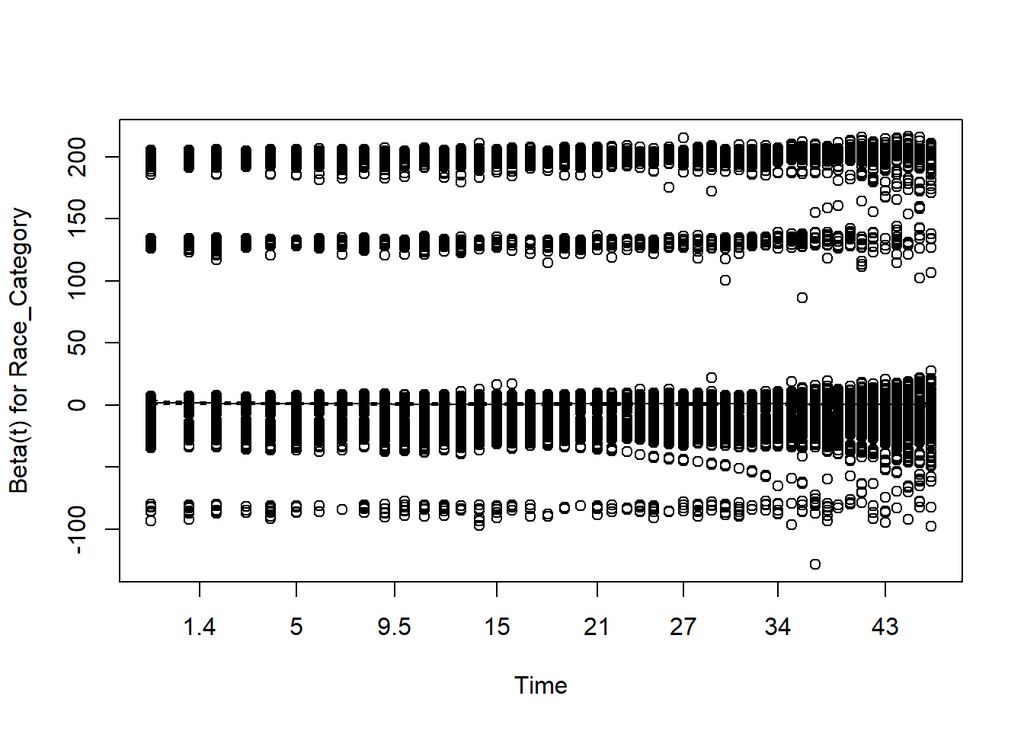

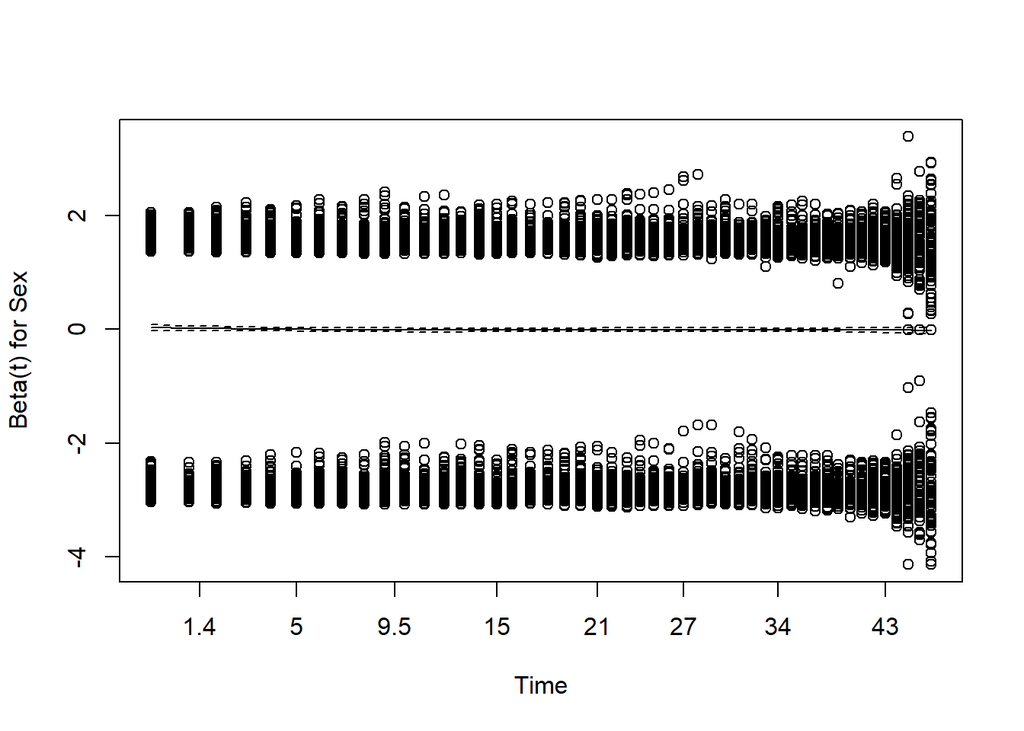

```r
plot(cox.zph_result_filtered)
```

For sex we have a non-significant p-value of .3592, indicating no strong evidence of a violation. However, for race_category we do violate our proportional hazards assumptions. This indicates that the effect of race on survival time changes over time. Because of this low p-value we decided to use interaction terms as well to see how our model improves.

#### Interaction Analysis with Renal Cancer

In the code below we used interaction terms and kept the strata of age. We used Race_Category as a interaction term.

```r
filtered_data <- filter(df_cleaned, Cancer_Group == "Renal Cancer")
cox_model_filtered <- coxph(Surv(Survival.months) ~ Race_Category * Sex + strata(Age), data = filtered_data)
cox_summary_filtered <- summary(cox_model_filtered)
table_data <- cox_summary_filtered$coefficients[, c("coef", "exp(coef)", "Pr(>|z|)")]
kable(table_data,
      caption = "Interaction for Renal Cancer Proportional Hazard Model Results",
      format = "html",
      align = "c",
      col.names = c("Coefficient", "Hazard Ratio", "p-value")) %>%
  kable_styling(bootstrap_options = "striped", full_width = FALSE)
```

Interaction for Renal Cancer Proportional Hazard Model Results

|  | Coefficient | Hazard Ratio | p-value |
| --- | --- | --- | --- |
| Race_CategoryBlack | -0.0980484 | 0.9066050 | 0.1244556 |
| Race_CategoryOther/Miscellaneous | -0.0438437 | 0.9571035 | 0.5088528 |
| Race_CategoryPacific Islander | 0.0640991 | 1.0661981 | 0.5868674 |
| Race_CategoryWhite | -0.0913472 | 0.9127008 | 0.1353077 |
| SexMale | -0.0726116 | 0.9299620 | 0.3309375 |
| Race_CategoryBlack:SexMale | 0.0891851 | 1.0932830 | 0.2579619 |
| Race_CategoryOther/Miscellaneous:SexMale | 0.1001984 | 1.1053902 | 0.2213712 |
| Race_CategoryPacific Islander:SexMale | -0.2164983 | 0.8053339 | 0.1544072 |
| Race_CategoryWhite:SexMale | 0.0679435 | 1.0703048 | 0.3671011 |

None of the individual race categories show a statistically significant impact on the hazard ratio, as indicated by their respective p-values. This suggests that, within the context of Renal Cancer and after accounting for age as a stratification variable, the hazard ratios for these race categories do not significantly differ. The coefficient for being male is -0.0726116, resulting in a hazard ratio of 0.9299620. This implies a decrease of 7.00% in the hazard of the event for males compared to females with Renal Cancer, as the p-value is 0.3309375. None of the interaction terms between Race_Category and being male are statistically significant. This indicates that the combined effect of race and sex on the hazard ratio does not significantly differ from the sum of their individual effects.

```r
cox_filtered_residuals <- residuals(cox_model_filtered, type = "martingale")
summary(cox_filtered_residuals)
```

```
   Min. 1st Qu.  Median    Mean 3rd Qu.    Max.
-5.5551 -0.3868  0.3056  0.0000  0.7122  0.9930
```

```r
cox.zph_result_filtered <- cox.zph(cox_model_filtered)
print(cox.zph_result_filtered)
```

```
                   chisq df      p
Race_Category     17.677  4 0.0014
Sex                0.878  1 0.3488
Race_Category:Sex 10.481  4 0.0331
GLOBAL            20.817  9 0.0135
```

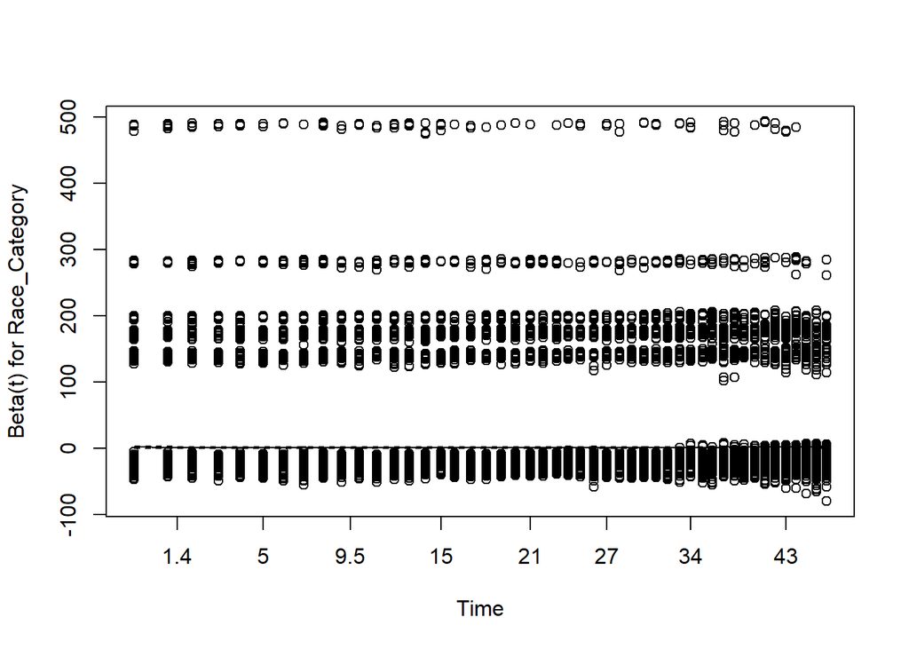

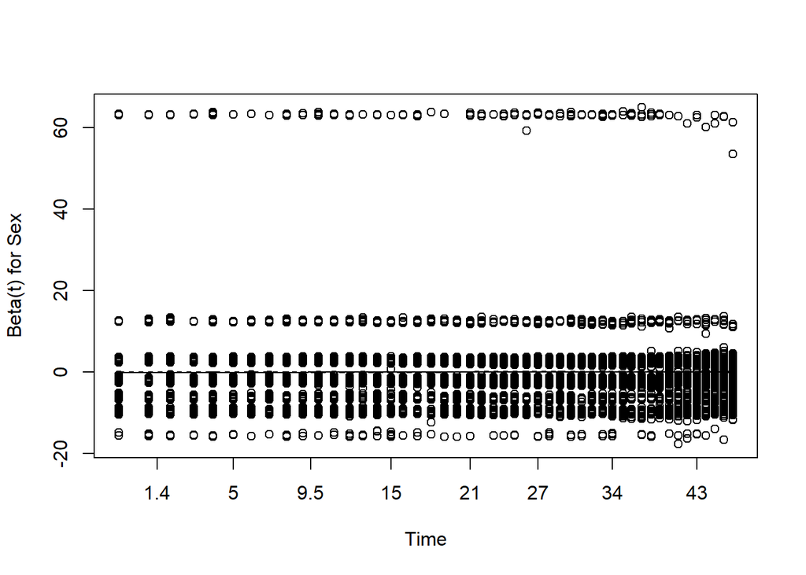

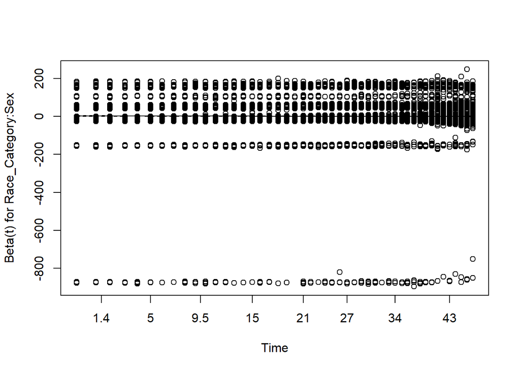

```r
plot(cox.zph_result_filtered)
```

Based on our p-values for the Schoenfield test, we are still violating the proportional hazards. Thus, we decided to do a similar approach as last time since Race_Category seems to be the issue. We decided to do the Binary_Race.

#### Filtering Analysis on Race with Renal Cancer

For the code below, we created the Binary_Race variable similar to how we did in with Thyroid Cancer. We made Binary_Race an interaction term as well and strata the variable age.

```r
filtered_data <- filter(df_cleaned, Cancer_Group == "Renal Cancer")
filtered_data$Binary_Race <- ifelse(filtered_data$Race_Category == "Black", "Black", "Other")
filtered_data$Binary_Race <- as.factor(filtered_data$Binary_Race)
levels(filtered_data$Binary_Race)
```

```
[1] "Black" "Other"
```

```r
cox_model_filtered <- coxph(Surv(Survival.months) ~ Binary_Race * Sex + strata(Age), data = filtered_data)

cox_summary_filtered <- summary(cox_model_filtered)
table_data <- cox_summary_filtered$coefficients[, c("coef", "exp(coef)", "Pr(>|z|)")]
kable(table_data,
      caption = "Binary Race for Renal Cancer Cox Proportional Hazard Model Results",
      format = "html",
      align = "c",
      col.names = c("Coefficient", "Hazard Ratio", "p-value")) %>%
  kable_styling(bootstrap_options = "striped", full_width = FALSE)
```

Binary Race for Renal Cancer Cox Proportional Hazard Model Results

|  | Coefficient | Hazard Ratio | p-value |
| --- | --- | --- | --- |
| Binary_RaceOther | 0.0125754 | 1.0126548 | 0.5541234 |
| SexMale | 0.0164791 | 1.0166157 | 0.5131259 |
| Binary_RaceOther:SexMale | -0.0214101 | 0.9788175 | 0.4257748 |

The coefficient for Binary_RaceOther is 0.0125754, resulting in a hazard ratio of 1.0126548. This implies an increase of 1.27% in the hazard of the event for individuals categorized as Other compared to those categorized as Black with Renal Cancer, as the p-value is 0.5541234. The coefficient for being male is 0.0164791, resulting in a hazard ratio of 1.0166157. This implies an increase of 1.65% in the hazard of the event for males compared to females with Renal Cancer, as the p-value is 0.5131259. The coefficient for the interaction term is -0.0214101, resulting in a hazard ratio of 0.9788175. This implies a decrease of 2.12% in the hazard of the event for individuals categorized as Other compared to those categorized as Black specifically among males, as the p-value is 0.4257748.

```r
cox_filtered_residuals <- residuals(cox_model_filtered, type = "martingale")
summary(cox_filtered_residuals)
```

```
   Min. 1st Qu.  Median    Mean 3rd Qu.    Max.
-5.2226 -0.3807  0.3050  0.0000  0.7118  0.9930
```

```r
cox.zph_result_filtered <- cox.zph(cox_model_filtered)
print(cox.zph_result_filtered)
```

```
                chisq df    p
Binary_Race     0.778  1 0.38
Sex             0.863  1 0.35
Binary_Race:Sex 0.149  1 0.70
GLOBAL          1.695  3 0.64
```

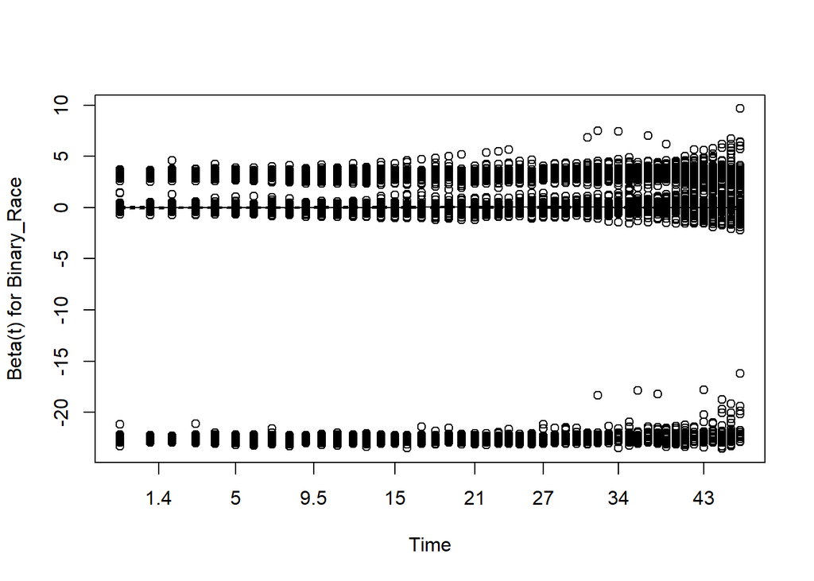

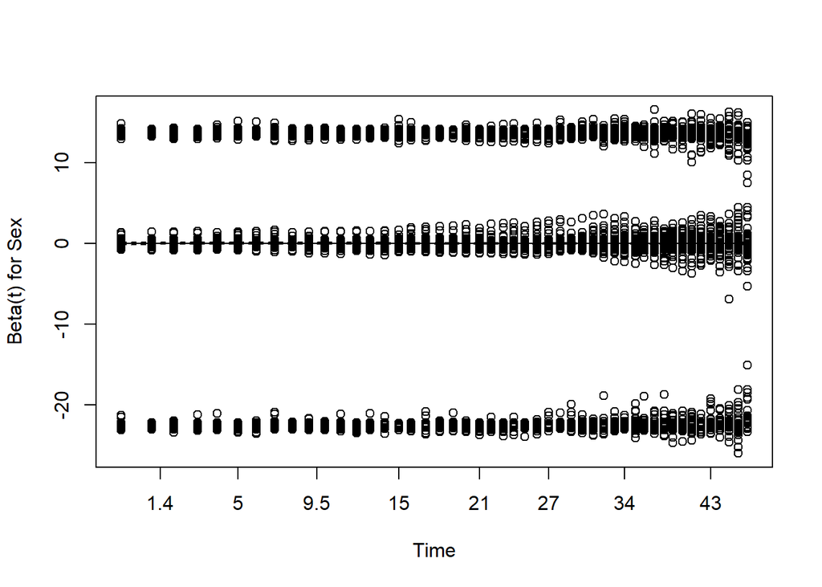

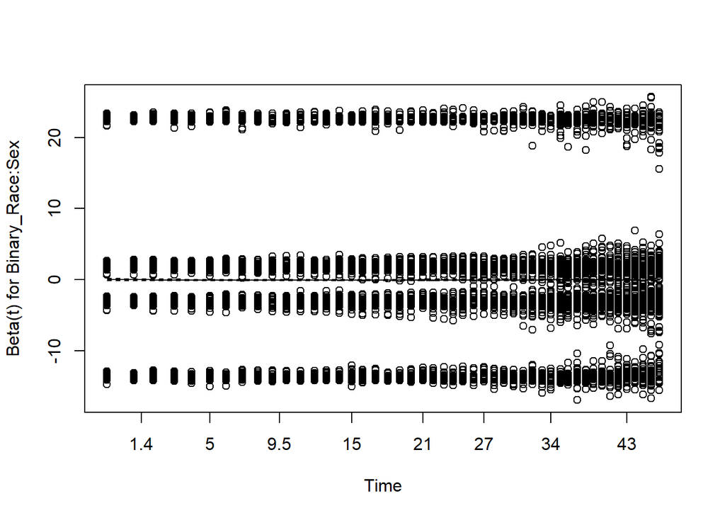

```r
plot(cox.zph_result_filtered)
```

The Schoenfeld test shows that none of the variables significantly violate the proportional hazards assumption individually. The GLOBAL test reinforces this, suggesting that, collectively, the variables do not provide strong evidence against the proportional hazards assumption. By editing the Race_Category we found that our model improved overall similar to what was done in our Thyroid Cancer analysis.